# Inference after prediciton simulation

## Overview

The main goal of this simulation approach is to evaluate our first approach to *inference after prediction*. The basic idea is to use a training set to quantify variation in prediction accuracy, so we can use that to correct inference using predicted outcomes in a new data set.

1. The ground truth. This represents the “state of nature”. We won’t know this model in real examples. Here we will simulate data from the model $y = g(\vec{x}) + e_g$ where $g()$ is a, possibly nonlinear, function of the covariates $\vec{x}$
2. The inferential model. For simplicity here we are are going to fit a linear model so $y = \vec{\beta}^T \vec{x} + e$. Here some subset of the $\vec{\beta}$ are what we care about when we are doing inference.
3. The prediction model. We will fit the prediction model $y_{p} = f(\vec{x})$ to get predicted values.
4. The model for the relationship between the predicted and real values which we assume is simple, $y_p = \gamma y + e_p$.
5. The inference after prediction model. Here we fit the model $y_{p} = \vec{\beta}_p \vec{x} + e_{iap}$ then use model 4 to correct the inference.

### Our goal

The goal for our approach is to use a training, testing, and validation set approach to try to correct the inference we do in the predicted data to match as closely as possible what we would have got using the real data.

So our goals are to create a corrected estimate $\hat{\beta}^*_p$

1. To correct our coefficient estimates so that $E[\hat{\beta} | y, \vec{x}] = E[\hat{\beta}^*_p | y_p, \vec{x}]$.
2. To correct our variance estimates so $Var[\hat{\beta} | y, \vec{x}] = Var[\hat{\beta}^*_p | y_p, \vec{x}]$
3. To correct our test statistics so $t[\hat{\beta} | y, \vec{x}] = t[\hat{\beta}^*_p | y_p, \vec{x}]$.

To do this we need to create corrected forms of the estimates, variances, and test statistics - denoted by a star. Since using them directly will not work.

### Our approach to IAP

We break the data into training, testing, and validation sets. We assume that in the training and testing set we have both the true outcome $y$ and the predicted outcome $y_p$. Using these data we do these steps.

1. We fit a model $y_{p} = f(\vec{x}_{i})$ in the training set.
2. In the testing data set we assume that there is a simple relationship between $y$ and $y_p$. In the case of continuous data we fit the model
   $$y_p = \gamma y + e_p$$
   where $e \sim N(0, \tau^2)$.
3. In the testing set we fit the model (1) $y_p = \beta_p \vec{x} + e_p$ to uncorrected $\hat{\beta}_p$ and the model (2) $y = \beta \vec{x} + e$
4. In the testing set we estimate the bias by calculating $\hat{b} = \hat{\beta}_p - \hat{\beta}$.
5. In the testing set we estimate
   $$Var[
   \hat{\beta}_p | y_p, \vec{x}] = (x^Tx)^{-1}x^T Var(y_p)x(x^Tx)^{-1} = (x^Tx)^{-1} Var(y_p)$$
   and we can calculate $Var(y_p) = \hat{\sigma}^2_p + \gamma^2\hat{\sigma}^2_y$

## Simulation set up

First we load all the libraries we will need

```r
library(dplyr)
library(tidyr)
library(caret)
```

```r
library(ggplot2)
library(broom)
library(reshape2)
```

Simulate the data with this code, the variable `x` is the covariate, `e` is the error, `set` is which of the training, testing or validation sets the value comes from, and `sim` is the simulation indicator. `ss` is the sample size in each set and `n_sim` is the number of simulations.

```r
ss = 200
n_sim = 20

sim_dat = data.frame(x = rnorm(ss*3),
                     e_g = rnorm(ss*3),
                     set = rep(c("training","testing","validation"),each=ss),
                     sim = 1)

for(i in 2:n_sim){
  sim_dat = rbind(sim_dat, data.frame(x = rnorm(ss*3),
                  e_g = rnorm(ss*3),
                  set = rep(c("training","testing","validation"),each=ss),
                  sim = i))
}

## Set the ground truth model
g = function(x){
  return(3  * x)
}

sim_dat = sim_dat %>% mutate(y = g(x) + e_g)
```

## Fit the prediction model

Here in the training set, we need to fit `f(x)` and we’ll use the caret package to do this.

```r
sim_dat_nested = sim_dat %>% nest(-set, -sim)

sim_dat_nested_train = filter(sim_dat_nested, set=="training") %>%
  mutate(model = purrr::map(data, ~  train(y ~ x, data = ., method = 'rf', importance = TRUE)))
```

## Get predicted values

In the testing and validation set, we fit the prediction model
$$y_p=f(\vec{x})$$
to get predicted values `pred`.

```r
sim_dat_nested_tv = lapply(1:n_sim,function(x){
  filter(sim_dat_nested,(set == "testing" | set == "validation") & sim == x) %>%
    mutate(pred = purrr::map(data, ~  predict(sim_dat_nested_train$model[[x]], data = .)))})

sim_dat_tv = sim_dat_nested_tv %>% do.call(rbind, .) %>% unnest()
```

## Correct our coefficient estimates

```r
sim_dat_tv_nested = sim_dat_tv %>% nest(-set, -sim) %>%
  mutate(yp_x = purrr::map(data, ~ tidy(lm(pred ~ x, data = .)))) %>%
  mutate(y_x = purrr::map(data, ~ tidy(lm(y ~ x, data = .))))

sim_dat_test_nested = filter(sim_dat_tv_nested, set == "testing") %>%
  mutate(bias = purrr::map(sim, function(x) {.$yp_x[[x]][-1,"estimate"] - .$y_x[[x]][-1,"estimate"]}))

sim_dat_val_nested = filter(sim_dat_tv_nested, set == "validation") %>%
  mutate(beta_BC = purrr::map(sim, function(x) {.$yp_x[[x]][-1,2] - sim_dat_test_nested$bias[[x]]}))
```

## Plot the relationship between the predicted and real values in the testing set.

The model for the relationship between the predicted and real values which we assume is simple,
$$y_p=\gamma y+e_p$$

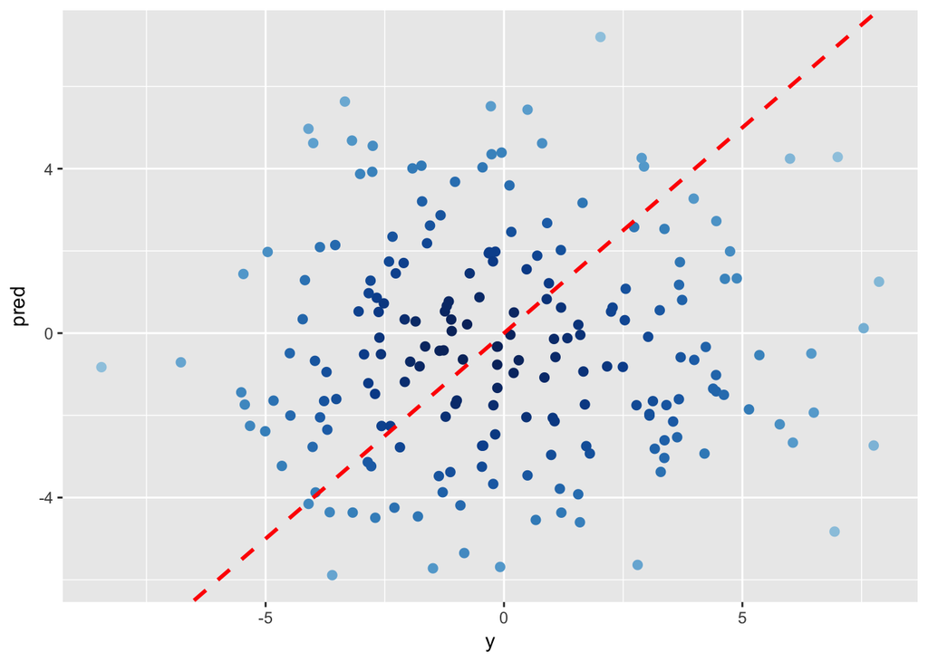

```r
sim_dat_test = filter(sim_dat_tv, set == "testing") %>% nest(-sim)
sim_dat_test = sim_dat_test %>%
  mutate(gg = purrr::map(data, ~ ggplot(data = ., aes(y, pred)) +
                           geom_point(color = densCols(.$y, .$pred, bandwidth = 2), size = 2) +
                           geom_abline(linetype="dashed",color="red",size=1)))

sim_dat_test$gg[[1]]
```

## Correct variance estimates

```r
sim_dat_test_nested = sim_dat_test_nested %>%
  mutate(yp_y = purrr::map(data, ~ tidy(lm(pred ~ y, data = .)))) %>%
  mutate(sigma_yx = purrr::map(data, ~ glance(lm(y ~ x, data = .)) %>% select(sigma))) %>%
  mutate(sigma_ypy = purrr::map(data, ~ glance(lm(pred ~ y, data = .)) %>% select(sigma)))


var_yp <- function(sim){
  gamma1 = sim_dat_test_nested$yp_y[[sim]][-1,"estimate"]
  sigma_p = sim_dat_test_nested$sigma_ypy[[sim]]
  sigma_y = sim_dat_test_nested$sigma_yx[[sim]]

  return(sigma_p + gamma1*sigma_y)
}


sim_dat_val_nested = sim_dat_val_nested %>%
  mutate(var_beta_BC = purrr::map(sim, function(sim){ x = cbind(rep(1, ss), .$data[[sim]] %>% select(x)) %>% as.matrix()
  var_beta_BC = solve(t(x) %*% x) * var_yp(sim)
  return(var_beta_BC) })) %>%
  mutate(se_beta_BC = purrr::map(sim, function(sim){ var_beta_BC[[sim]] %>% sqrt()}))
```

## Find t statistics

Here we find t statistics $t_{BC}$ for testing null hypothesisL
$$H_0 : \beta = 0$$
using bias corrected estimator `beta_BC` and standard error of the estimator `se_beta_BC`.

$$t_{BC} = \frac{\hat{\beta}_{BCest} -0} {se_{\hat{\beta}_{est}}}$$

```r
sim_dat_val_nested = sim_dat_val_nested %>% mutate(t_BC = purrr::map(sim, function(x){ .$beta_BC[[x]] / .$se_beta_BC[[x]]}))
```

## Compare a few more statistics

1. $t_{BC}$ calculated above.
2. $t_{iap}$ comes from fitting the inference after prediction model $y_{p} = \vec{\beta}_p \vec{x} + e_{iap}$.
3. $t_{true}$ comes from fitting the model $y = \vec{\beta} \vec{x} + e$, but in reality we cannot obtain t_true$ because true values y are unknown in the validation set.
4. $t_{iap-BCbeta}$ comes from fitting the inference after prediction model $y_{p} = \vec{\beta}_p \vec{x} + e_{iap}$ but uses bias corrected $\beta$.
5. $t_{iap-BCse}$ comes from fitting the inference after prediction model $y_{p} = \vec{\beta}_p \vec{x} + e_{iap}$ but uses bias corrected standard error.

```r
sim_dat_val_nested = sim_dat_val_nested %>%
  mutate(t_iap = purrr::map(sim, function(x){ .$yp_x[[x]][-1,"statistic"]})) %>%
  mutate(t_true = purrr::map(sim, function(x){ .$y_x[[x]][-1,"statistic"]})) %>%
  mutate(t_iap_BCbeta = purrr::map(sim, function(x){ t_BC = .$beta_BC[[x]] / .$yp_x[[x]][-1,"std.error"]})) %>%
  mutate(t_iap_BCse = purrr::map(sim, function(x){ t_BC = .$yp_x[[x]][-1,"estimate"] / .$se_beta_BC[[x]]}))
```

## Plot t statistics

```r
t_df <- sim_dat_val_nested %>% select(t_true, t_iap, t_BC, t_iap_BCbeta, t_iap_BCse) %>% unnest() %>% data.frame()
colnames(t_df) <- c("t_true","t_iap","t_iap_BCbeta","t_BC", "t_iap_BCse")
t_df <- t_df %>% melt()
```

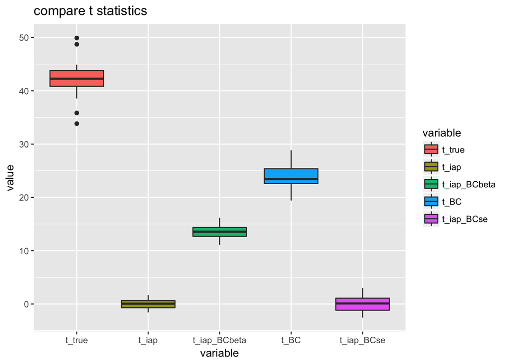

```r
t_plot <- ggplot(t_df, aes(x = variable, y = value, fill=variable)) +
                       geom_boxplot() +
                       ggtitle("compare t statistics")
t_plot
```